# exploring-dosage

Amy Burkhardt

5/4/2020

In this file, I explore the extent to which there is a linear relationship between the number of coaching sessions and the three outcome variables. There tends to be a linear relationship, but there is some evidence that, on average, there is actually a negative relationship between coaching and invited term gpa, as well as coaching and next semester credits for students who have more than 6 coaching sesssions.

## Coaching Sessions and Invited Term GPA

First, let’s take a look at the relationship between the number of coaching sessions a student receives and the outcome variable, “Invited Term GPA”).

The correlation between these two variables is .21.

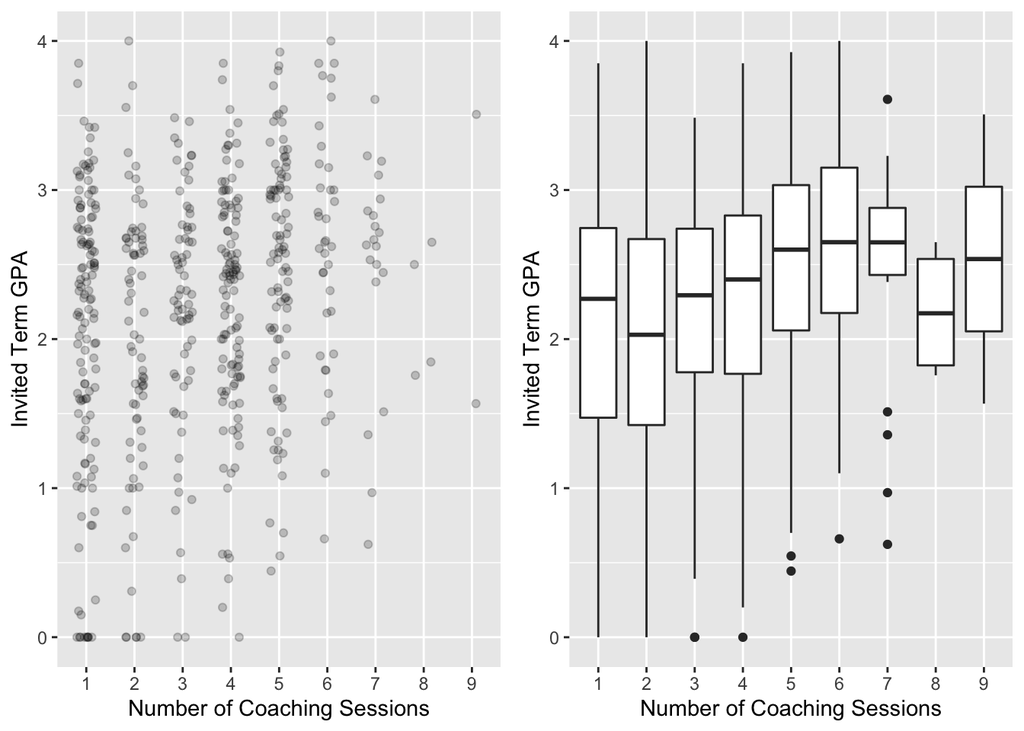

### Exploring the linearity of the relationships

The red dotted line is the linear model line. The blue dotted line is the General Additive Model, which allows us to assess how non-linear the relationship may be. Here, it seems that the relationship is linearly until about 7 sessions at which point there is some deviation from the linearity.

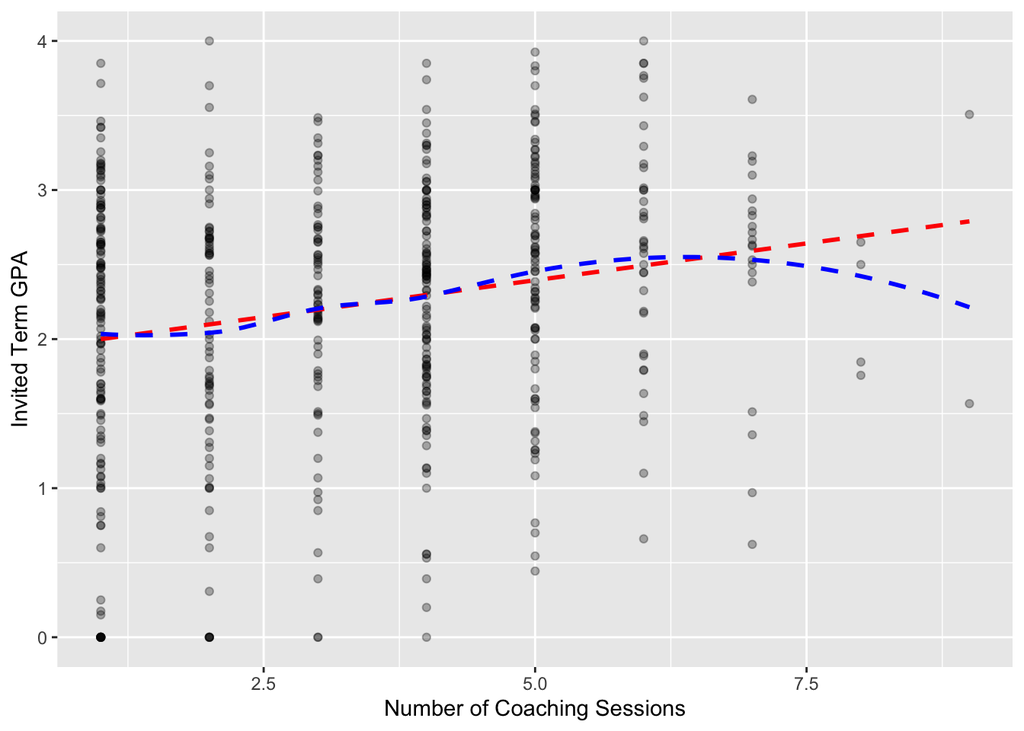

## Coaching Sessions and Next Semester Credits

First, let’s take a look at the relationship between the number of coaching sessions a student receives and the outcome variable, “Next Semester Credits”).

The correlation between these two variables is .13.

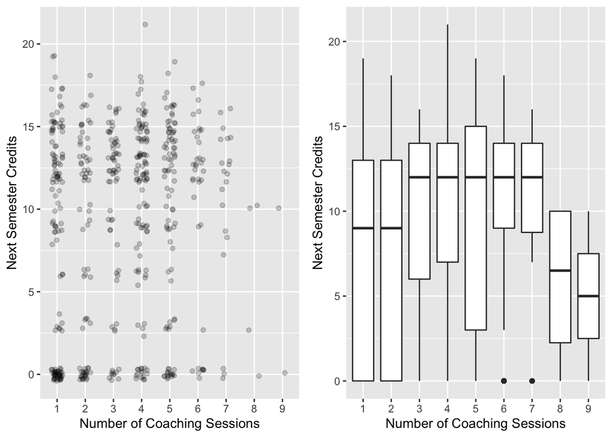

### Exploring the linearity of the relationship

The red dotted line is the linear model line. The blue dotted line is the General Additive Model, which allows us to assess how non-linear the relationship may be. Once again, it seems that the relationship is linear until about 6 sessions at which point there is some deviation from the linearity.

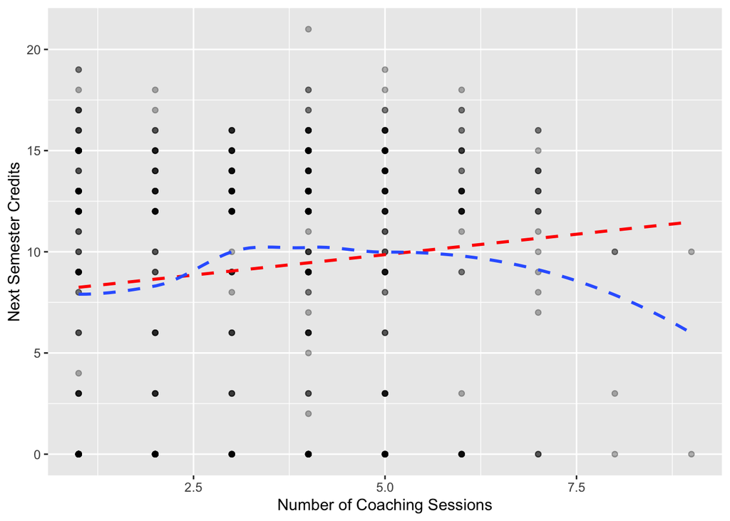

## Coaching Sessions and Enrolled Next Semester

First, let’s take a look at the relationship between the number of coaching sessions a student receives and the outcome variable, “Enrolled Next Semester”).

The correlation between these two variables is .15.

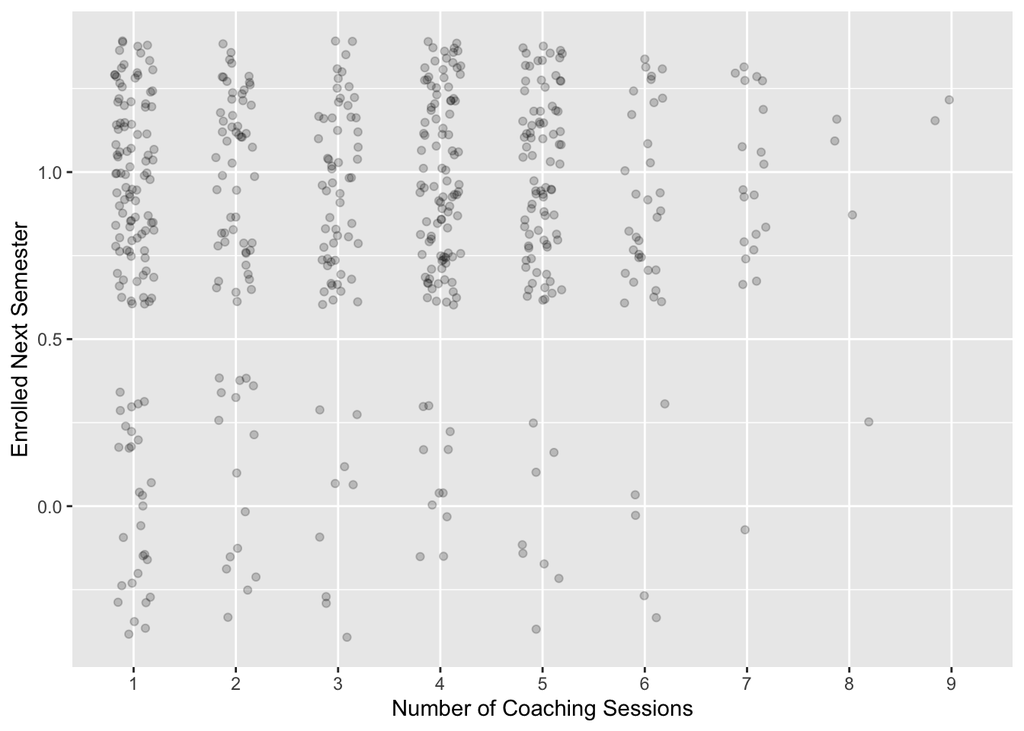

### Exploring the linearity of the relationship

[figure not shown]